# Project2

190030150

03/11/2019

1. Executive summary
2. Introduction
3. Methods

Bootstrapping, randomization and model selection explained detailly. Linear regression mentioned but not explained in detail

Results

Conclusion

```r
library(leaps)
library(ggvis)
library(parallel)
library(lmtest)
myData <- read.csv("fitness.csv")
```

```r
myMode<- regsubsets(Oxygen~., data = myData)
```

```r
summaryModel <-summary(myMode)
summaryModel
```

```
## Subset selection object
## Call: regsubsets.formula(Oxygen ~ ., data = myData)
## 6 Variables  (and intercept)
##           Forced in Forced out
## Age           FALSE      FALSE
## Weight        FALSE      FALSE
## RunTime       FALSE      FALSE
## RestPulse     FALSE      FALSE
## RunPulse      FALSE      FALSE
## MaxPulse      FALSE      FALSE
## 1 subsets of each size up to 6
## Selection Algorithm: exhaustive
##          Age Weight RunTime RestPulse RunPulse MaxPulse
## 1  ( 1 ) " " " "    "*"     " "       " "      " "
## 2  ( 1 ) "*" " "    "*"     " "       " "      " "
## 3  ( 1 ) "*" " "    "*"     " "       "*"      " "
## 4  ( 1 ) "*" " "    "*"     " "       "*"      "*"
## 5  ( 1 ) "*" "*"    "*"     " "       "*"      "*"
## 6  ( 1 ) "*" "*"    "*"     "*"       "*"      "*"
```

This returns the best model for each variable number of paramets the star represents that. Lets check which model return the best BIC

```r
names(summaryModel)
```

```
## [1] "which"  "rsq"    "rss"    "adjr2"  "cp"     "bic"    "outmat" "obj"
```

```r
summaryModel$rsq
```

```
## [1] 0.7433801 0.7642469 0.8110945 0.8368181 0.8480018 0.8486719
```

```r
summaryModel$bic
```

```
## [1] -35.29696 -34.49212 -37.92581 -39.02966 -37.79656 -34.49955
```

```r
par(mfrow=c(2,2))
plot(summaryModel$rss ,xlab="Number of Variables ",ylab="RSS",type="l")
plot(summaryModel$adjr2 ,xlab="Number of Variables ", ylab="Adjusted RSq",type="l")
# which.max(summaryModel$adjr2)
points(11,summaryModel$adjr2[11], col="red",cex=2,pch=20)
plot(summaryModel$cp ,xlab="Number of Variables ",ylab="Cp", type='l')
# which.min(summaryModel$cp )
points(10,summaryModel$cp [10],col="red",cex=2,pch=20)
plot(summaryModel$bic ,xlab="Number of Variables ",ylab="BIC",type='l')
# which.min(summaryModel$bic )
points(6,summaryModel$bic [6],col="red",cex=2,pch=20)
```

[output not shown]

BIC is lowest for four variables we will choose the model with four variables

```r
coef(myMode,4)
```

```
## (Intercept)         Age     RunTime    RunPulse    MaxPulse
##  98.1478880  -0.1977347  -2.7675788  -0.3481079   0.2705130
```

```r
regfit.fwd = regsubsets(Oxygen ~. , data=myData,nvmax=19, method ="forward")
regfit.bwd = regsubsets(Oxygen ~. , data=myData,nvmax=19,method ="backward")
forwardModel <-summary(regfit.fwd)
backwardModel <-summary(regfit.bwd)
```

```r
forwardModel
```

```
## Subset selection object
## Call: regsubsets.formula(Oxygen ~ ., data = myData, nvmax = 19, method = "forward")
## 6 Variables  (and intercept)
##           Forced in Forced out
## Age           FALSE      FALSE
## Weight        FALSE      FALSE
## RunTime       FALSE      FALSE
## RestPulse     FALSE      FALSE
## RunPulse      FALSE      FALSE
## MaxPulse      FALSE      FALSE
## 1 subsets of each size up to 6
## Selection Algorithm: forward
##          Age Weight RunTime RestPulse RunPulse MaxPulse
## 1  ( 1 ) " " " "    "*"     " "       " "      " "
## 2  ( 1 ) "*" " "    "*"     " "       " "      " "
## 3  ( 1 ) "*" " "    "*"     " "       "*"      " "
## 4  ( 1 ) "*" " "    "*"     " "       "*"      "*"
## 5  ( 1 ) "*" "*"    "*"     " "       "*"      "*"
## 6  ( 1 ) "*" "*"    "*"     "*"       "*"      "*"
```

```r
backwardModel
```

```
## Subset selection object
## Call: regsubsets.formula(Oxygen ~ ., data = myData, nvmax = 19, method = "backward")
## 6 Variables  (and intercept)
##           Forced in Forced out
## Age           FALSE      FALSE
## Weight        FALSE      FALSE
## RunTime       FALSE      FALSE
## RestPulse     FALSE      FALSE
## RunPulse      FALSE      FALSE
## MaxPulse      FALSE      FALSE
## 1 subsets of each size up to 6
## Selection Algorithm: backward
##          Age Weight RunTime RestPulse RunPulse MaxPulse
## 1  ( 1 ) " " " "    "*"     " "       " "      " "
## 2  ( 1 ) "*" " "    "*"     " "       " "      " "
## 3  ( 1 ) "*" " "    "*"     " "       "*"      " "
## 4  ( 1 ) "*" " "    "*"     " "       "*"      "*"
## 5  ( 1 ) "*" "*"    "*"     " "       "*"      "*"
## 6  ( 1 ) "*" "*"    "*"     "*"       "*"      "*"
```

```r
par(mfrow=c(2,2))
plot(forwardModel$rss ,xlab="Number of Variables ",ylab="RSS",type="l")
plot(forwardModel$adjr2 ,xlab="Number of Variables ", ylab="Adjusted RSq",type="l")
# which.max(forwardModel$adjr2)
points(11,forwardModel$adjr2[11], col="red",cex=2,pch=20)
plot(forwardModel$cp ,xlab="Number of Variables ",ylab="Cp", type='l')
# which.min(forwardModel$cp )
points(10,forwardModel$cp [10],col="red",cex=2,pch=20)
plot(forwardModel$bic ,xlab="Number of Variables ",ylab="BIC",type='l')
# which.min(forwardModel$bic )
points(6,forwardModel$bic [6],col="red",cex=2,pch=20)
```

[output not shown]

```r
par(mfrow=c(2,2))
plot(backwardModel$rss ,xlab="Number of Variables ",ylab="RSS",type="l")
plot(backwardModel$adjr2 ,xlab="Number of Variables ", ylab="Adjusted RSq",type="l")
# which.max(backwardModel$adjr2)
points(11,backwardModel$adjr2[11], col="red",cex=2,pch=20)
plot(backwardModel$cp ,xlab="Number of Variables ",ylab="Cp", type='l')
# which.min(backwardModel$cp )
points(10,backwardModel$cp [10],col="red",cex=2,pch=20)
plot(backwardModel$bic ,xlab="Number of Variables ",ylab="BIC",type='l')
# which.min(backwardModel$bic )
points(6,backwardModel$bic [6],col="red",cex=2,pch=20)
```

[output not shown]

Our independent variables will be runTime Age, RunPulse and maxPulse

Paralellization

```r
 nCores <- detectCores()

  # Create a cluster with all but one core of PC
  myClust <- makeCluster(nCores-1, type = "PSOCK")
```

```r
lmBootOptimisedOnce <- function(index, inputData, indexResponse, indexCov){

  # convert to data-frame if already not
  inputData = as.data.frame(inputData)

  dataDim <- nrow(inputData)#find number of rows


  bootData <- inputData[sample(1:dataDim, dataDim, replace = T),] #Resample
  bootData <- as.matrix(bootData)

  # Adding a column of 1s to the design matrix
  Xmat <- cbind(1, bootData[ , indexCov])
  Ymat <- bootData[ , indexResponse]

  # fast version of linear model (need R version 3.1.0)
  # https://rpubs.com/maechler/fast_lm
  model <- .lm.fit(Xmat, Ymat)

  return(coef(model))
}
```

```r
lmBootOptimisedPar <- function(nBoot, myData, indexResponse, indexCov){

  bootCoefList <- parLapply(myClust, 1:nBoot, lmBootOptimisedOnce,
                            inputData = myData,
                            indexResponse = indexResponse,
                            indexCov = indexCov)

  bootCoefs <- plyr::ldply(bootCoefList)

  # closing cluster
  stopCluster(myClust)

  return(bootCoefs)
}
```

```r
response <- 3 # Pick oxygen as response value
covariates <- c(1,4,5,6)
```

```r
bootResults <-(lmBootOptimisedPar(5000,myData,response,covariates))
```

```r
confInv <-rbind(quantile(bootResults[,1], probs = c(0.025, 0.975)),
  quantile(bootResults[,2], probs = c(0.025, 0.975)),quantile(bootResults[,3], probs = c(0.025, 0.975)),quantile(bootResults[,4], probs = c(0.025, 0.975)),quantile(bootResults[,5], probs = c(0.025, 0.975)))
```

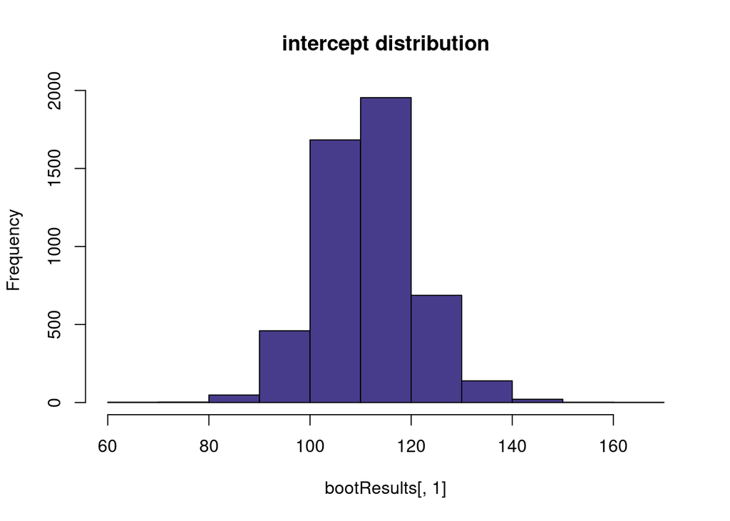

```r
 hist(bootResults[,1], col = "slateblue4", main = 'intercept distribution')
```

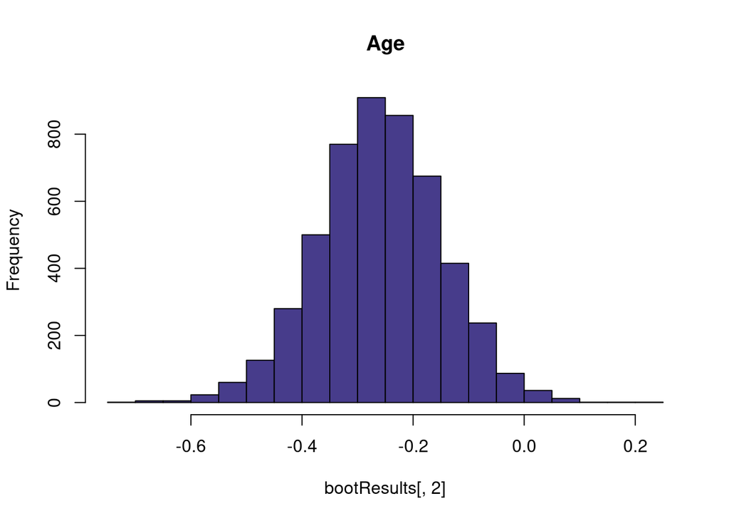

```r
  hist(bootResults[,2], col = "slateblue4", main = 'Age')
```

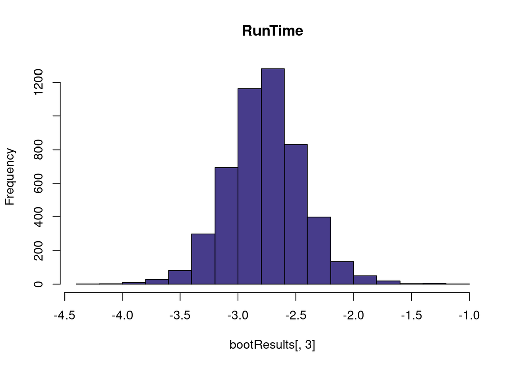

```r
    hist(bootResults[,3], col = "slateblue4", main = 'RunTime')
```

[figure not shown]

```r
      hist(bootResults[,4], col = "slateblue4", main = 'RunPulse')
```

[figure not shown]

```r
        hist(bootResults[,5], col = "slateblue4", main = 'MaxPulse')
```

```r
  # our best guesses of parameters
means <-  c(mean(bootResults[,1]), mean(bootResults[,2]), mean(bootResults[,3]), mean(bootResults[,4]), mean(bootResults[,5]))
```

```r
myMod <-summary(lm(Oxygen~Age+RunTime+RunPulse+MaxPulse, data = myData))
```

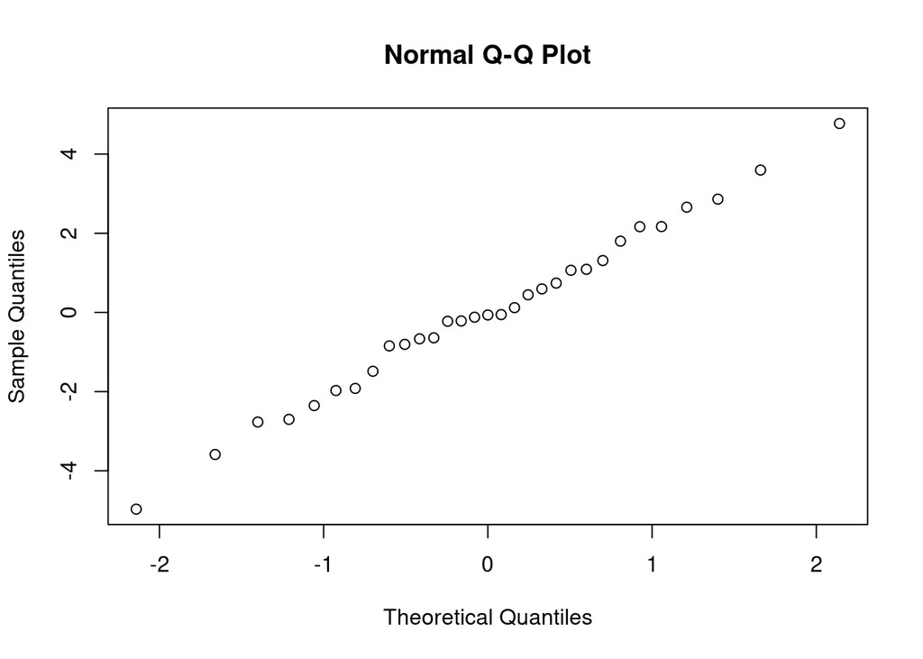

```r
qqnorm(myMod$residuals)
```

```r
shapiro.test(myMod$residuals)
```

```
##
##  Shapiro-Wilk normality test
##
## data:  myMod$residuals
## W = 0.99406, p-value = 0.9997
```

Dont reject p value -> normality assumption fulfilled

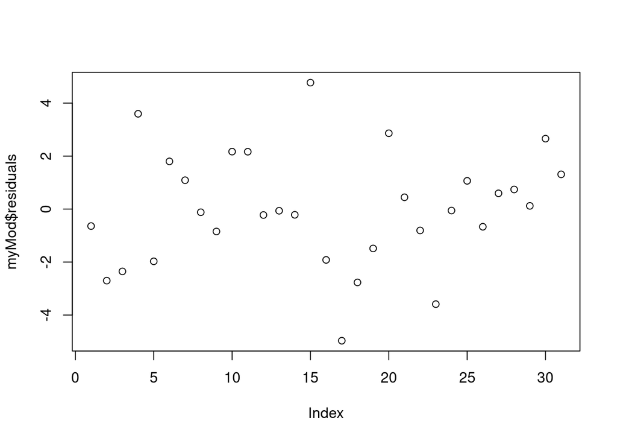

```r
plot(myMod$residuals)
```

Variance looks constant -> formal test

```r
bptest(myMod)
```

```
##
##  studentized Breusch-Pagan test
##
## data:  myMod
## BP = 3.0597, df = 4, p-value = 0.5479
```

```r
estimatedMean <- mean(myData$Oxygen)
```

```r
t.test(myData$Oxygen, mu = 0)
```

```
##
##  One Sample t-test
##
## data:  myData$Oxygen
## t = 49.515, df = 30, p-value < 2.2e-16
## alternative hypothesis: true mean is not equal to 0
## 95 percent confidence interval:
##  45.42176 49.32985
## sample estimates:
## mean of x
##  47.37581
```

```r
 simResults <- numeric(999)

  for(i in 1: 999){

    # get the sampling distribution
    simResults[i] <- mean(sample(myData$Oxygen, 100, replace = T))

  }

  # if H0 is true, it is centred on zero
  simResults <- simResults - estimatedMean
```

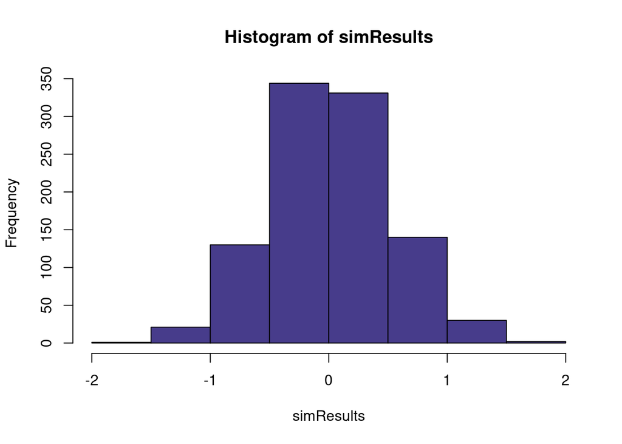

```r
hist(simResults, col = "slateblue4")

  abline(v = estimatedMean, lwd = 3)
```

```r
  addEst <- c(estimatedMean, simResults)

  locEst <- c(1, rep(0, 999))

  locEst<- locEst[order(addEst)]

  k <- which(locEst == 1)

  min(k/1000, 1-k/1000)*2
```

```
## [1] 0
```

```r
meanIntercept <- means[1]
meanAge <- means[2]
meanRunTime <- means[3]
meanRunPulse <- means[4]
meanMaxPulse <- means[5]
```

```r
simResults <- numeric(999)
simResults1 <- numeric(999)
simResults2<- numeric(999)
simResults3 <- numeric(999)
simResults4 <- numeric(999)

  simData <- myData

  for(i in 1: 999){
    # shuffle the x WRT y
    simData$y <- sample(myData$Oxygen,31, replace = T)

    # fit a model under H0
    simLM <- lm(y ~ Age + RunTime + RunPulse + MaxPulse, data = simData)

    #store the slope
    simResults[i] <- coef(simLM)[1]
    simResults1[i] <- coef(simLM)[2]
    simResults2[i] <- coef(simLM)[3]
    simResults3[i] <- coef(simLM)[4]
    simResults4[i] <- coef(simLM)[5]

  }
```

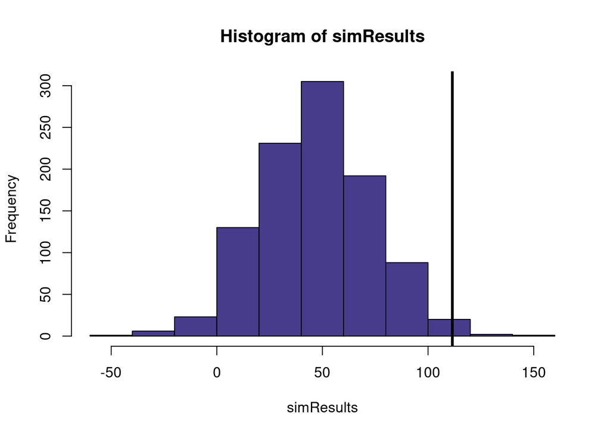

```r
 hist(simResults, col = "slateblue4")

  abline(v = means[1], lwd = 3)
```

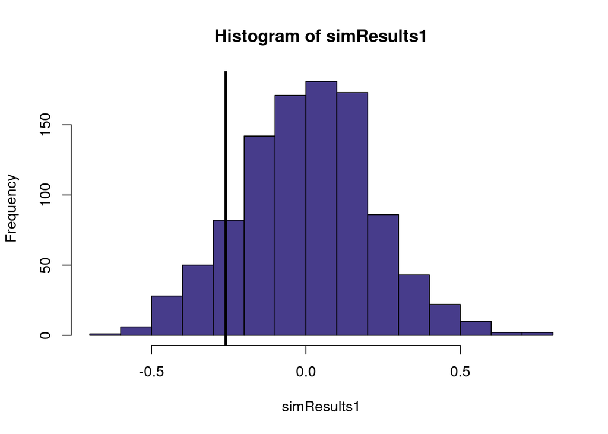

```r
 hist(simResults1, col = "slateblue4")

  abline(v = means[2], lwd = 3)
```

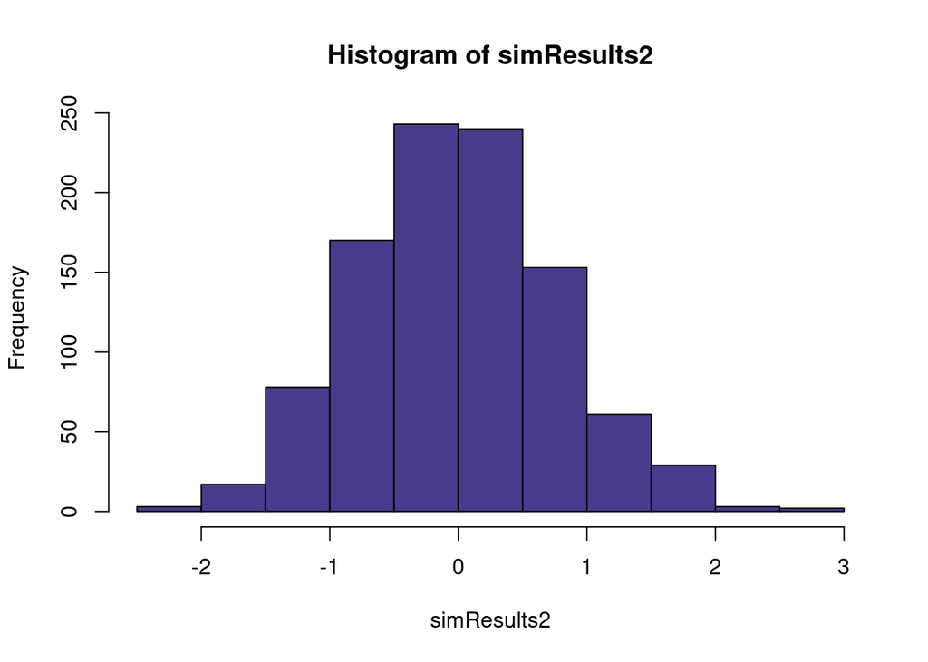

```r
 hist(simResults2, col = "slateblue4")

  abline(v = means[3], lwd = 3)
```

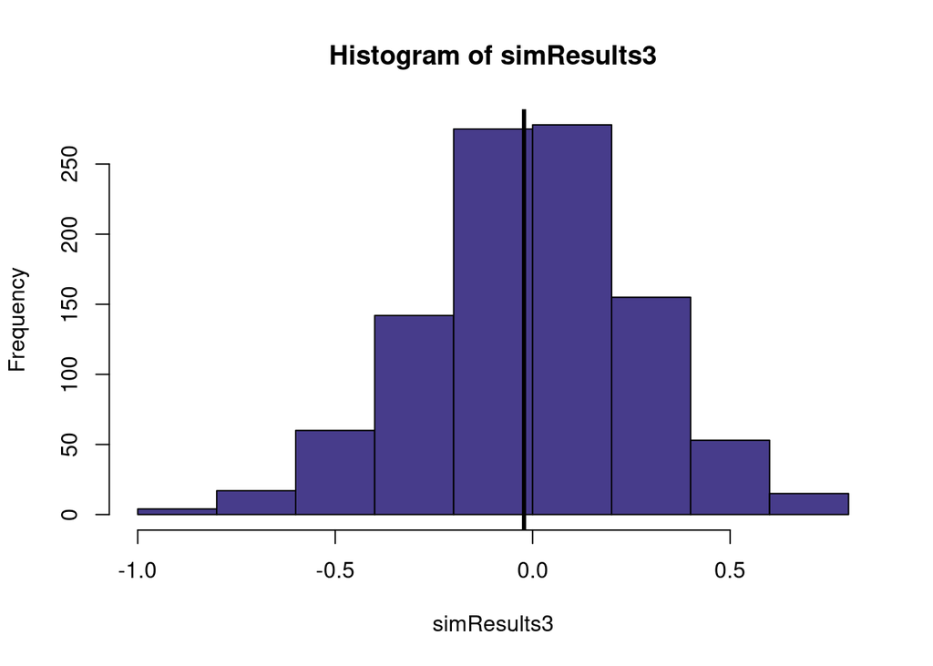

```r
 hist(simResults3, col = "slateblue4")

  abline(v = means[4], lwd = 3)
```

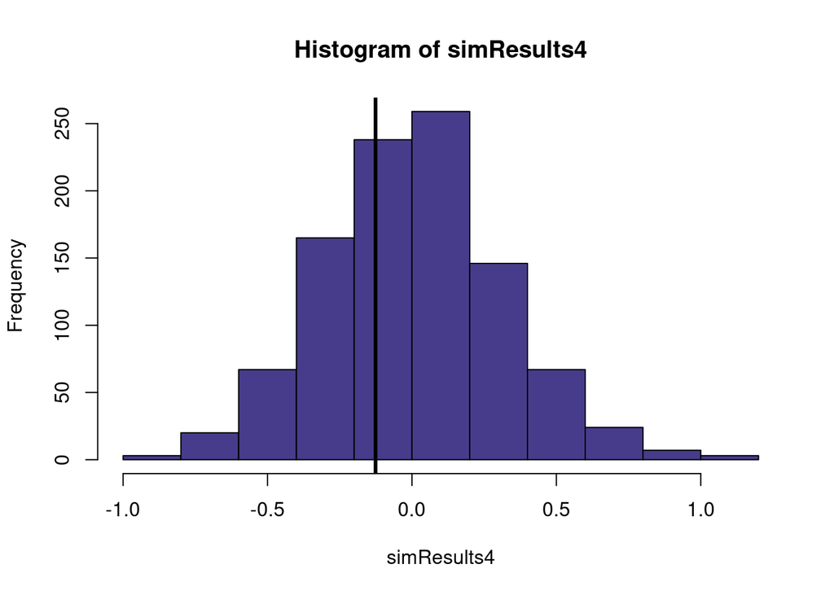

```r
 hist(simResults4, col = "slateblue4")

  abline(v = means[5], lwd = 3)
```

```r
addEst <- c(means[1], simResults)

  locEst <- c(1, rep(0, 999))

  locEst<- locEst[order(addEst)]

  k <- which(locEst == 1)

  min(k/1000, 1-k/1000)*2
```

```
## [1] 0.016
```

```r
addEst <- c(means[2], simResults1)

  locEst <- c(1, rep(0, 999))

  locEst<- locEst[order(addEst)]

  k <- which(locEst == 1)

  min(k/1000, 1-k/1000)*2
```

```
## [1] 0.236
```

```r
addEst <- c(means[3], simResults2)

  locEst <- c(1, rep(0, 999))

  locEst<- locEst[order(addEst)]

  k <- which(locEst == 1)

  min(k/1000, 1-k/1000)*2
```

```
## [1] 0.002
```

```r
addEst <-c(means[4], simResults3)

  locEst <- c(1, rep(0, 999))

  locEst<- locEst[order(addEst)]

  k <- which(locEst == 1)

  min(k/1000, 1-k/1000)*2
```

```
## [1] 0.932
```

```r
addEst <- c(means[5], simResults4)

  locEst <- c(1, rep(0, 999))

  locEst<- locEst[order(addEst)]

  k <- which(locEst == 1)

  min(k/1000, 1-k/1000)*2
```

```
## [1] 0.672
```

Talk about the data and what our goal is. Make a linear model predicting oxygen intake based on predictors. And state which methods we will use to achieve that goal. Show a table of mean and standard deviance of each variable.`

Best subset selection (backwards, forwards)

Randomization

Bootstrapping

Check if assumptions are fulfilled

Results of bootstrap -> Confidence intervals and means which are the coefficients. Histograms go here.

Interpret effects of coefficients. State which is statistically significant and which are not. Discuss R-squared and what that means for the model.

Randomization test -> gives us p-values which we can say are signinficant or not.